# Atividade 1

Author

Mikael Marin Coletto

Published

November 20, 2024

# Questão 1

Um instituto de pesquisa afirma que um determinado produto possui 50% de aceitação por parte dos consumidores. Em uma amostra de 180 consumidores, observaram-se 100 pessoas declarando rejeição e 80 declarando aceitação para com o produto. Teste a afirmação dada pelo instituto, adotando-se α=5%. (Dá pra fazer tanto por qui-quadrado, quanto binomial. Escolha um.)

R: Como possuímos uma amostra grande (mais de 30) usaremos uma aproximação pela normal. Também usaremos como hipótese nula que a proporção de aceitação é de 50% e como hipótese alternativa que a proporção de aceitação é diferente de 50%.

H0: p = 0.5 H1: p != 0.5

```r
n = 180 # Tamanho da amostra
aceitacao = 80 # Número de pessoas que aceitaram
rejeicao = 100 # Número de pessoas que rejeitaram

p = aceitacao/n
q = 1 - p
x = 80 # Menor frequência

zcalc = ((x-n*p)/(sqrt(n*p*q)))
# zcalc
# p_value <- pnorm(zcalc)

binom.test(80,180,0.5)
```

```
    Exact binomial test

data:  80 and 180
number of successes = 80, number of trials = 180, p-value = 0.1565
alternative hypothesis: true probability of success is not equal to 0.5
95 percent confidence interval:
 0.3705325 0.5202165
sample estimates:
probability of success
             0.4444444
```

```r
####Encontrando no R probabilidades utilizando a normal
p_value <- pnorm(zcalc)

#teste <- binom.test(aceitacao, n, p=0.5, alternative="less")

if(p_value < 0.05){
  print("Rejeitamos H0, ou seja, há evidências para aceitar de que a proporção de aceitação é diferente de 50%") ## Proporção diferente de 50%
}else{
  print("Não rejeitamos H0, ou seja, não há evidências para aceitar de que a proporção de aceitação é diferente de 50%") ## Proporção igual à 50%
}
```

```
[1] "Não rejeitamos H0, ou seja, não há evidências para aceitar de que a proporção de aceitação é diferente de 50%"
```

```r
# Dados observados
observado <- c(80, 100)  # aceitação, rejeição
n <- 180

# Teste qui-quadrado
esperado <- c(n/2, n/2)  # frequência esperada sob H0
esperado_prop <- esperado/n  # ajuste para a soma ser igual a observada
teste <- chisq.test(observado, p = esperado_prop)

# Resultados
print(teste)
```

```
    Chi-squared test for given probabilities

data:  observado
X-squared = 2.2222, df = 1, p-value = 0.136
```

```r
# Alternativa usando prop.test
prop.test(80, 180, p=0.5)
```

```
    1-sample proportions test with continuity correction

data:  80 out of 180, null probability 0.5
X-squared = 2.0056, df = 1, p-value = 0.1567
alternative hypothesis: true p is not equal to 0.5
95 percent confidence interval:
 0.3710924 0.5202061
sample estimates:
        p
0.4444444
```

```r
if(teste$p.value < 0.05){
  print("Rejeitamos H0, ou seja, há evidências para aceitar de que a proporção de aceitação é diferente de 50%") ## Proporção diferente de 50%
}else{
  print("Não rejeitamos H0, ou seja, não há evidências para aceitar de que a proporção de aceitação é diferente de 50%") ## Proporção igual à 50%
}
```

```
[1] "Não rejeitamos H0, ou seja, não há evidências para aceitar de que a proporção de aceitação é diferente de 50%"
```

# Questão 2

Deseja-se testar a hipótese de que os resultados das faces de um dado tem uniformidade de ocorrência. Para tanto, joga-se o mesmo o numero de vezes mostrado abaixo, anotando-se os resultados:

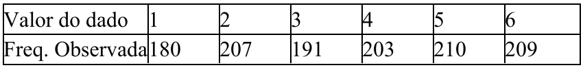

Tabela 1

Execute um teste qui-quadrado. Utilize α=5%.

H0: p1 = p2 = p3 = p4 = p5 = p6 (As faces do dado tem uniformidade de ocorrência) H1: Pelo menos uma das probabilidades é diferente (As faces do dado não tem uniformidade de ocorrência)

```r
# Dados observados
observado <- c(180, 207, 191, 203, 210, 209)  # frequências observadas
n <- sum(observado)
qtd_freq <- length(observado)
esperado <- rep(n/qtd_freq, qtd_freq)  # frequência esperada sob H0
esperado_prop <- esperado/n  # proporção esperada sob H0

# Teste qui-quadrado
teste <- chisq.test(observado, p = esperado_prop)

# Resultados
print(teste)
```

```
    Chi-squared test for given probabilities

data:  observado
X-squared = 3.6, df = 5, p-value = 0.6083
```

```r
if(teste$p.value < 0.05){
  print("Rejeitamos H0, ou seja, não há evidências para aceitar a afirmação de que os resultados das faces de um dado tem uniformidade de ocorrência")
}else{
  print("Não rejeitamos H0, ou seja, não há evidências para rejeitar a afirmação de que os resultados das faces de um dado tem uniformidade de ocorrência")
}
```

```
[1] "Não rejeitamos H0, ou seja, não há evidências para rejeitar a afirmação de que os resultados das faces de um dado tem uniformidade de ocorrência"
```

Portanto, concluímos que, com base no teste qui-quadrado, não há evidências para rejeitar a afirmação de que os resultados das faces de um dado tem uniformidade de ocorrência. Ou seja, podemos dizer que as probabilidades de ocorrência de cada face do dado são iguais.

# Questão 3

24 crianças foram avaliadas com relação a um índice de agressividade e em seguida converteram-se os dados em sinais positivos (+) e negativos (-), dependendo se o índice estava acima ou abaixo da mediana do grupo. Deseja-se verificar a aleatoriedade dos escores de agressividade com relação à ordem em que foram obtidos.

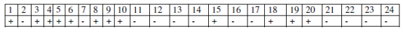

Tabela 2

Verificar a aleatoriedade dos escores.

H0: Os escores são aleatórios H1: Os escores não são aleatórios

```r
# Dados observados
dados <- data.frame(
  posicao = 1:24,
  sinal = c("a","b","a","a","a","a","b","a","a","a","b","b","b","b","a","b","b","a","a","a","b","b","b","b")
)

teste <- DescTools::RunsTest(dados$sinal)

if(teste$p.value < 0.05){
  print("Rejeitamos H0, ou seja, não há evidências para aceitar a afirmação de que os escores são aleatórios")
}else{
  print("Não rejeitamos H0, ou seja, não há evidências para rejeitar a afirmação de que os escores são aleatórios")
}
```

```
[1] "Não rejeitamos H0, ou seja, não há evidências para rejeitar a afirmação de que os escores são aleatórios"
```

Portanto, concluímos que, com base no teste de aleatoriedade dos escores, não há evidências para rejeitar a afirmação de que os escores são aleatórios. Ou seja, podemos dizer que os escores de agressividades são aleatórios.

# Questão 4

Um fabricante de autopeças garante que o diâmetro de eixos produzidos por sua fábrica segue uma distribuição normal com média 100 mm e desvio padrão 2 mm. Teste a afirmação considerando a amostra de 6 peças obtidas e o teste de Kolmogorov Smirnov ao nível de 5% de significância:

R: Testar Distribuição normal, média 100mm e desvio padrão 2mm. Usando o teste de kolmogorov e nível de significância de 5%.

H0: A distribuição dos diâmetros segue uma distribuição normal com média 100 mm e desvio padrão 2 mm. H1: A distribuição dos diâmetros não segue uma distribuição normal com média 100 mm e desvio padrão 2 mm.

```r
# Dados observados
amostra <- c(93.45, 96.74, 97.93, 100.73, 103.60, 105.20)  # diâmetros observados

# Teste de Kolmogorov-Smirnov
teste <- ks.test(amostra, "pnorm", mean=100, sd=2)

# Resultados
print(teste)
```

```
    Exact one-sample Kolmogorov-Smirnov test

data:  amostra
D = 0.34967, p-value = 0.3679
alternative hypothesis: two-sided
```

```r
if(teste$p.value < 0.05){
  print("Rejeitamos H0, ou seja, não há evidências para aceitar a afirmação de que a distribuição dos diâmetros segue uma distribuição normal com média 100 mm e desvio padrão 2 mm")
}else{
  print("Não rejeitamos H0, ou seja, não há evidências para rejeitar a afirmação de que a distribuição dos diâmetros segue uma distribuição normal com média 100 mm e desvio padrão 2 mm")
}
```

```
[1] "Não rejeitamos H0, ou seja, não há evidências para rejeitar a afirmação de que a distribuição dos diâmetros segue uma distribuição normal com média 100 mm e desvio padrão 2 mm"
```

Portanto, concluímos que, com base no teste de Kolmogorov-Smirnov, não há evidências para rejeitar a afirmação de que a distribuição dos diâmetros segue uma distribuição normal com média 100 mm e desvio padrão 2 mm, ou seja, podemos dizer que as peças seguem os parâmetros indicados pelo fabricante.

# Questão 5

Refaça pelo teste de Lilliefors, o exemplo feito em sala de aula sobre o peso das carnes nas refeições do restaurante. (Testar Normalidade) α=5%.

R:

H0: A distribuição dos pesos das carnes segue uma distribuição normal. H1: A distribuição dos pesos das carnes não segue uma distribuição normal.

```r
# Dados observados
amostra <- c(198, 254, 262, 272, 275, 278, 285, 287, 287, 292)  # pesos observados

# Teste de Lilliefors
teste <- nortest::lillie.test(amostra)

# Resultados
print(teste)
```

```
    Lilliefors (Kolmogorov-Smirnov) normality test

data:  amostra
D = 0.24322, p-value = 0.09606
```